# ACS_LT4 Final Project_16 Sept 2021

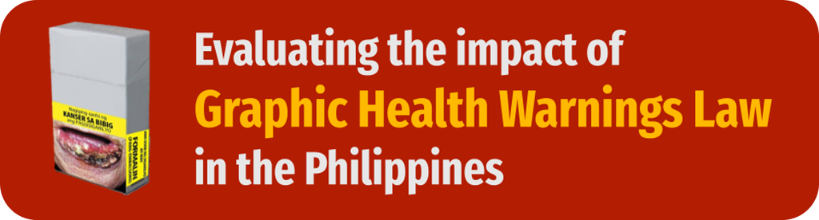

by Kashmirr Camacho, Kristine Ann Carandang, Weddy Diamada,  
John Francis Gacal, Manuel John Paul Gaspar, and Joaquin Emmanuel Gonzales

Applied Computational Statistics | MSDS 2022 | Asian Institute of Management

Submitted 16 September 2021

# Executive Summary

*Motivation*

Last July 2013, the Philippines passed Republic Act 10643, which is popularly known as The Graphic Health Warnings Law. This was in response to the World Health Organization’s research that text warnings were shown to be insufficient in conveying the risks of tobacco products in an individual's health. Illustrations or pictures have been empirically validated as more effective in conveying the truth about the dangers of cigarette consumption. In this study, we explore the main research question, **“Does the Graphic Health Warnings Law have an impact on tobacco consumption?”**

*Data and Methodology*

We used the cross-section data of the Global Adult Tobacco Surveys (GATS) conducted in the Philippines during 2009 and 2015. The GATS is a household survey conducted in different countries, which aims to monitor different tobacco control indicators.

In answering the main research question, we broke down our research approach into 3 sub-questions. These sub-questions and the corresponding methodologies are described as follows:

| No. | Research sub-questions | Methodology or tests applied |
| --- | --- | --- |
| 1 | Is there a significant difference between the number of cigarettes being smoked by active smokers between 2009 or 2015? If there is, did cigarette consumption go higher or lower from 2009 to 2015? | **Two Proportion Z-Test** to test if there is a significant difference between the proportion of smokers in 2009 and 2015. **Mann-Whitney U test** to test if there is a significant difference between … |
| 2 | Are there significant differences in the amount of cigarette consumption of individuals across different income classifications? How about their educational attainment? | **Kruskal-Wallis H-test** to test if there is a significant difference between median consumption across different groups (i.e. highest educational attainment and income bracket of smokers). **Conover… |
| 3 | What are the factors that have an increasing effect on the probability of smoking cessation? Does exposure to cigarette health warnings influence current smokers to try quitting their smoking habits? | **Logistic regression** to infer which factors significantly affect a smoker’s consideration in quitting given their exposure to health warnings across different media. |

*Key insights*

The key insights in this study are as follows:

1. There is a statistically significant difference between the proportion of smokers in 2009 and 2015, specifically, the share of smokers decreased in the latter year. However, the median daily cigarette consumption of active smokers remains the same at 10 cigarette sticks per day. On the basis of sex at birth, male smokers consume more than twice the amount of cigarettes as female smokers in both years.
2. Smokers with a monthly income of PHP3,500 and below generally have significantly lower consumption of cigarettes than higher-income earners. Similarly, smokers with no formal schooling or elementary graduates consume fewer cigarettes than those with higher educational attainment.
3. Being a female, a high-income earner (more than PHP21,000 monthly income), a post-secondary undergraduate/graduate, or a high school undergraduate/graduate, increases the odds of quitting smoking. On the other hand, working outside of the home and having smokers inside a household decrease the odds of quitting smoking.
4. Exposure to information about the dangers of smoking or encouragement to quit in TV, magazines, and health care facilities such as hospitals encourages smokers to try quitting.

*Conclusion and Recommendations*

We evaluated the effect of graphic health warnings in reducing cigarette consumption among Filipinos by using statistical tests to detect the presence of significant differences in cigarette consumption between the years 2009 and 2015, in income classifications, and in educational attainment. Our study suggests that there are select mediums for graphic health warnings that have shown to be effective in influencing a smoker’s consideration to quit the habit. We encourage the use of diverse media platforms to continue influencing Filipinos, especially active smokers, towards a healthier lifestyle.

# Introduction

## Overview

Cigarette smoking has contributed to the deterioration of health outcomes of Filipinos. Globally, the World Health Organization (WHO) has posited that 80% of worldwide smokers come from developing countries such as the Philippines. The health governing body has also reported that around 87,600 Filipinos die annually due to tobacco-related diseases (WHO, 2020). Not only does smoking cause harm to the user, it also generates negative externalities towards other people. 14% of smoking-related deaths worldwide are caused by exposure to secondhand smoke from cigarettes (WHO, 2020). Moreover, increased amounts of smoking activity has reduced an individual’s consumption set for all other necessities. A report by the American Cancer Society argues that Filipinos would have to spend 6.45% of their income yearly so that they can satiate their need to smoke daily (Drope, et al., 2018). This makes it difficult for poorer households, who have members with a higher likelihood of smoking, to rise out of poverty.

Likewise, the Philippines’ Department of Health (DOH) suggests that the Philippines spends Php 188 billion yearly on hospitalization expenditures, medicine, and all other forms of treatment that are associated with only four out of 40 known smoking-related diseases - namely lung cancer, chronic obstructive pulmonary disease, heart disease, and stroke (DOH, n.d.). Smoking also has generated adverse environmental effects in the Philippines. Proper cigarette butt disposal is not evident in most public areas in the country. There are around 37,000 tons of cigarette butts and packaging that end up in different dump sites around the Philippines each year (DOH, n.d.). When cigarette butts are not disposed of properly, it contributes to land, air, and water pollution which stems from toxic chemicals emitted by such waste. With all the social, economic, and environmental repercussions that the practice of cigarette smoking has generated in the Philippines, it is imperative that the government must put into priority major initiatives and programs that would curb down the propensity of Filipinos to consume cigarette products.

There have been laws and public policies enacted by the Philippine government in order to disincentivize smoking behavior. Former president Gloria Macapagal-Arroyo has passed the Republic Act 9211, which regulates the packaging, use, sale, and the distribution of tobacco products. Major guidelines enacted in the law include the prohibition of smoking in public places such as universities, recreational facilities, hospitals, and public transportation (Tobacco Regulation Act of 2003). Sale of tobacco products to minors aged eighteen years of age and below was also prohibited, and advertisements of tobacco products must always indicate a disclaimer that smoking is dangerous to one’s health. Cigarette packages were required to have printed text warnings that enumerate the risks of smoking. Although the law took into account the welfare of Filipinos, it also took into account the tradeoffs of the policy to different stakeholders in the tobacco industry. While smoking incidence throughout the Arroyo administration showed signs of decline, it remained to be persistently high. 30.6% and 27.6% of Filipinos aged 15 years and above were regular smokers in 2005 and 2010, respectively (The World Bank, n.d.).

The 15th Congress of the Philippines, coinciding with Benigno Aquino’s presidency, passed RA 10351, or An Act Restructuring the Excise Tax on Alcohol and Tobacco Products - a policy that restructures the excise tax on alcohol and tobacco products (Republic Act 10351, 2012). The policy led to the imposition of an ad-valorem tax equal to 20 percent of the net retail price on all cigarette products, excluding the previously imposed value-added tax to consumer goods. It also added a specific tax, initially set at five pesos per cigarette stick, which increases every year after 2013 by 4%.

Concurrently, the same administration passed the Republic Act 10643, popularly known as the Graphic Health Warnings Law, to fully inform every Filipino on the health repercussions of smoking, and to protect Filipinos from the adverse interests of the stakeholders in the tobacco industry (Republic Act 10643, 2012). Among its implementing guidelines include the printing of a photographic warning of the possible effects of smoking to an individual’s health, which is accompanied by an appropriate textual warning that explains the visual representation. This graphic warning must cover 50% of each side of the cigarette box. Likewise, cigarette boxes are now forbidden to put descriptors such as ‘low tar’, ‘mild’, ‘light’, or ‘ultra light’ which may lead to erroneous public perception that some cigarettes are less harmful compared to other brands or types. Lawmakers recognized that text warnings have been proven to be empirically insufficient in cascading to individuals the adverse effects of smoking in a person’s health. An empirical study made by the WHO, which was cited by the law, argues that pictorial and graphic warnings tend to be more effective in enlightening individuals on the dangers of habitual cigarette smoking. During the Aquino administration, smoking incidence among Filipinos aged fifteen years and above have decreased by an average of 0.60% yearly (An Act Restructuring the Excise Tax on Alcohol and Tobacco Products, 2012).

Recently in 2019, during the Duterte Administration, the Universal Health Care Act (Republic Act No. 11223) was enacted to improve health outcomes of Filipinos and prevent non-communicable diseases - which includes tobacco-related diseases. With the persistent incidence of tobacco-related diseases as mentioned above, this study seeks to help policymakers prioritize programs that will minimize tobacco consumption among Filipinos.

## Research questions

Considering the policy initiatives of the government in reducing the cigarette consumption of Filipinos especially on the effect of graphic health warnings, the researcher seeks to answer the following questions for this study:

1. Is there a significant difference between the number of cigarettes being smoked by active smokers between 2009 or 2015? If there is, did cigarette consumption go higher or lower from 2009 to 2015?
2. Are there significant differences in the amount of cigarette consumption of individuals across different income classifications? How about their educational attainment?
3. What are the factors that have an increasing effect on the probability of smoking cessation? Does exposure to cigarette health warnings influence current smokers to try quitting their smoking habits?

## Scope and limitations

We evaluated a few limitations of this report, and have taken steps to minimize them wherever possible:

1. **Data verification.** This study is limited to the published data on the Philippines as part of GATS. It is a household survey on adult tobacco use and control measures created by WHO. The GATS is made publicly available periodically, but we did not implement any additional verification measures to check validity of our downloaded data in the interest of time.
2. **Time period.** We limited our coverage to the data available, which is on the years 2009 and 2015. We selected these two years because it is where most of the laws relevant to smoke cessation and control were passed in Congress. We think that selecting these years is sufficient to surface the desired insights in line with our research questions.

# Methodology

To answer the research questions, the researchers employed the following methodology as shown in Figure 1. Each step is discussed in the next few sections.

**Figure 1. Process flow of this study**  
Each step is discussed in the next few sections

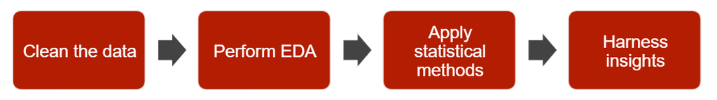

## Data Cleaning

The GATS data for 2009 and 2015 of the Philippines was downloaded from the Non-communicable Disease Microdata Repository of WHO.

```python
# install the posthocs library
!pip install scikit_posthocs

# Load libraries needed for the analysis
import pandas as pd
import numpy as np
import matplotlib.pyplot as plt
import seaborn as sns
import pandas as pd
import numpy as np
import matplotlib.pyplot as plt

# import libraries for the statistical tests
import statsmodels.api as sm
import scikit_posthocs as sp
from statsmodels.stats.outliers_influence import variance_inflation_factor
from scipy.stats import norm, kstest, mannwhitneyu, levene, kruskal
pd.options.display.float_format = "{:,.5f}".format

# Import packages to handle warnings
import warnings
from warnings import simplefilter
from sklearn.exceptions import ConvergenceWarning
warnings.filterwarnings("ignore", category=FutureWarning)
warnings.filterwarnings("ignore", category=RuntimeWarning)
warnings.filterwarnings("ignore", category=ConvergenceWarning)
from pandas.core.common import SettingWithCopyWarning
warnings.simplefilter(action="ignore", category=SettingWithCopyWarning)
from sklearn.exceptions import DataConversionWarning
warnings.filterwarnings(action='ignore', category=DataConversionWarning)

# load the color palette
colors = ['#ffb900ff', '#b31d01ff']
sns.set_palette(sns.color_palette(colors))
```

```python
# load the GATS 2009 Survey Data
gats_2009 = pd.read_csv('GATS 2009 Survey Data.csv', index_col=0,
                        low_memory=False)
gats_2009['2015'] = gats_2009.apply(lambda row: 0, axis=1)
gats_2009['b06a'] = pd.to_numeric(gats_2009['b06a'], errors='coerce')
gats_2009 = gats_2009[gats_2009['f01d'] != 'refused']

# count number of smokers in the entire household, including respondent
data = gats_2009[['hh4e001', 'hh4e002', 'hh4e003', 'hh4e004', 'hh4e005',
                  'hh4e006', 'hh4e007', 'hh4e008', 'hh4e009', 'hh4e010']]
data = data.replace({2: 0, 7: 0})
data['smoker_count_in_hh'] = data.sum(axis=1)
gats_2009 = pd.merge(gats_2009, data['smoker_count_in_hh'],
                     left_index=True, right_index=True)

# for respondents that answered the number of cigarettes they smoked weekly
# instead of daily we divided their response by seven
def week_smokers(col1, col2):
    """Return daily intake for weekly frequencies of cigarette consumption."""
    if col1 == 'r smokes product but not every day' or col1 == 888:
        return col2 / 7
    else:
        return col1

gats_2009['daily_cigarette_intake'] = gats_2009.apply(lambda x:
                                                      week_smokers(x['b06a'],
                                                                   x['b06a1']),
                                                      axis=1)

# gats 2009 cigarette price per stick
cols = ['f01b', 'f01c', 'f01d']
gats_2009[cols] = gats_2009[cols].fillna(1)
gats_2009['f01d'] = pd.to_numeric(gats_2009['f01d'], errors='coerce')
gats_2009['f02'] = pd.to_numeric(gats_2009['f02'], errors='coerce')
gats_2009['cigarette_price'] = gats_2009['f02'] / (gats_2009['f01b'] *
                                                   gats_2009['f01c'] *
                                                   gats_2009['f01d'])
```

```python
# load the GATS 2015 Survey Data
gats_2015 = pd.read_csv('GATS 2015 Survey Data.csv', index_col=0,
                        low_memory=False)
gats_2015['AGE'] = gats_2015['AGE'].astype(int)
gats_2015.columns = [x.lower() for x in list(gats_2015.columns)]
gats_2015 = gats_2015.rename(columns={'aa06': 'aa6', 'ff2': 'ff7a'})
gats_2015 = gats_2015.applymap(lambda s:s.lower() if type(s) == str else s)
gats_2015['2015'] = gats_2015.apply(lambda row: 1, axis=1)


# count number of smokers in the entire household, including respondent
data = gats_2015[['hh4e01', 'hh4e02', 'hh4e03', 'hh4e04', 'hh4e05',
                  'hh4e06', 'hh4e07', 'hh4e08', 'hh4e09', 'hh4e10',
                  'hh4e11', 'hh4e12', 'hh4e13', 'hh4e14', 'hh4e15',
                  'hh4e16', 'hh4e17', 'hh4e18', 'hh4e19', 'hh4e20']]
data = data.replace({'no': 0, 'yes': 1, "don't know": 0})
data['smoker_count_in_hh'] = data.sum(axis=1)
gats_2015 = pd.merge(gats_2015, data['smoker_count_in_hh'],
                     left_index=True, right_index=True)

# for respondents that answered the number of cigarettes they smoked weekly
# instead of daily we divided their response by seven
to_replace = {'b06a': {'888': 'r smokes product but not every day'},
              'aa6': {'21.000 to 29,999': '21,000 or higher',
                       '30,000 to 39,999': '21,000 or higher',
                       '40,000 to 49,999': '21,000 or higher',
                       '50,000 or higher': '21,000 or higher',
                       '8,500 to 19,999': '8,500 to 20,999',
                       '20,000 to 20,999': '8,500 to 20,999'},
             'hh4e': {2: 0},
             'f02': {9999: np.nan}}
gats_2015 = gats_2015.replace(to_replace)
gats_2015['daily_cigarette_intake'] = gats_2015.apply(lambda x:
                                                      week_smokers(x['b06a'],
                                                                   x['b06a1']),
                                                      axis=1)

# cigarette price smoking 2015
gats_2015[['f01bcig', 'f01bpack', 'f01bcart', 'f01bother', 'f01dpack',
           'f01dpacka','f01dcart', 'f01dcarta', 'f01dother']] = \
gats_2015[['f01bcig', 'f01bpack', 'f01bcart', 'f01bother', 'f01dpack',
           'f01dpacka','f01dcart', 'f01dcarta', 'f01dother']].fillna(1)
gats_2015['f01dpack'] = pd.to_numeric(gats_2015['f01dpack'], errors='coerce')
gats_2015['f01dcart'] = pd.to_numeric(gats_2015['f01dcart'], errors='coerce')
gats_2015['cigarette_price'] = gats_2015['f02'] / \
(gats_2015['f01bcig'] * gats_2015['f01bpack'] *
 gats_2015['f01bcart'] * gats_2015['f01bother'] *
 gats_2015['f01dpack'] * gats_2015['f01dpacka'] * gats_2015['f01dcart'] *
 gats_2015['f01dcarta']*gats_2015['f01dother'])
```

```python
# pooling the two datasets together

relevant_cols = ['2015', 'gatscluster', 'gatsweight', 'residence', 'age',
                 'hh1', 'hh2', 'hh4e', 'smoker_count_in_hh',
                 'a01', 'a04', 'aa6', 'b01', 'b04', 'daily_cigarette_intake',
                 'b07', 'd01', 'e01', 'e04', 'cigarette_price', 'f01a',
                 'ff7a', 'g01a', 'g01b', 'g01c', 'g01d', 'g01d1', 'g01d2',
                 'g01d3', 'g01d4', 'g02', 'g03', 'g04a', 'g04b', 'g04c',
                 'g04d', 'g04e', 'g04f', 'g04g', 'g04h', 'g04i', 'g04j']
gats_pooled = pd.concat([gats_2009, gats_2015], axis=0)[relevant_cols]
gats_pooled = gats_pooled.replace({'residence': {'urban': 0, 1: 0, 'rural': 1,
                                                 2: 1},
                                   'a01': {'male': 0, 'female': 1},
                                   'hh4e': {'yes': 1, 'no': 0,
                                            7: 0, 9: 0, 'don\'t know': 0},
                                   'b04': {99: np.nan,
                                           "don't know/refused": np.nan},
                                   'aa6': {'don\x92T KNOW': 'don\'t know',
                                           'donâ€™t know': 'don\'t know'},
                                   'f01a': {'cartons': 'packs',
                                            'other specify': 'packs'},
                                   'd01': {'yes': 1, 'no': 0,
                                           'refused': 0}})
col_names = {'hh1': 'hh_member_count', 'hh2': 'hh_adult_count',
             'hh4e': 'smoker', 'a01': 'female', 'residence': 'rural',
             'b01': 'smoking_freq', 'b04': 'age_started_smoking',
             'aa6': 'income_bracket', 'a04': 'highest_educ_attainment',
             'b07': 'mins_before_first_smoke', 'e01': 'hh_smoking_rules',
             'e04': 'work_outside_home', 'ff7a': 'price_sensitive_smoker',
             'g01a': 'quit_magazine', 'g01b': 'quit_tv', 'g01c': 'quit_radio',
             'g01d': 'quit_billboard', 'g01d1': 'quit_trains',
             'g01d2': 'quit_cinema', 'g01d3': 'quit_hospitals',
             'g01d4': 'quit_malls', 'g02': 'seen_health_warnings_on_packaging',
             'g03': 'quit_health_warnings_on_packaging',
             'g04a': 'promote_cig_stores', 'g04b': 'promote_cig_tv',
             'g04c': 'promote_cig_radio', 'g04d': 'promote_cig_billboard',
             'g04e': 'promote_cig_poster', 'g04f': 'promote_cig_magazine',
             'g04g': 'promote_cig_cinema', 'g04h': 'promote_cig_internet',
             'g04i': 'promote_public_transpo', 'g04j': 'promote_public_walls',
             'd01': 'tried_stop_smoking', 'f01a': 'last_cig_bought'}
gats_pooled = gats_pooled.rename(columns=col_names)
gats_pooled['age_started_smoking'] = \
pd.to_numeric(gats_pooled['age_started_smoking'])

# save the transformed dataset as a csv file
gats_pooled.to_csv('gats_pooled.csv')
gats_pooled
```

|  | 2015 | gatscluster | gatsweight | rural | age | hh_member_count | hh_adult_count | smoker | smoker_count_in_hh | female | ... | promote_cig_stores | promote_cig_tv | promote_cig_radio | promote_cig_billboard | promote_cig_poster | promote_cig_magazine | promote_cig_cinema | promote_cig_internet | promote_public_transpo | promote_public_walls |
| --- | --- | --- | --- | --- | --- | --- | --- | --- | --- | --- | --- | --- | --- | --- | --- | --- | --- | --- | --- | --- | --- |
| 0 | 0 | 15,052.00000 | 1,874.02858 | 1 | 57.00000 | 2.00000 | 1.00000 | 0.00000 | 0.00000 | 1 | ... | no | no | no | no | no | no | no | no | no | no |
| 1 | 0 | 15,052.00000 | 1,712.91402 | 1 | 53.00000 | 3.00000 | 3.00000 | 1.00000 | 1.00000 | 0 | ... | no | no | no | no | no | no | no | no | no | no |
| 2 | 0 | 15,052.00000 | 2,328.71996 | 1 | 85.00000 | 3.00000 | 3.00000 | 0.00000 | 0.00000 | 1 | ... | yes | no | no | no | no | no | no | no | no | no |
| 3 | 0 | 15,052.00000 | 1,900.30712 | 1 | 51.00000 | 5.00000 | 3.00000 | 1.00000 | 1.00000 | 0 | ... | yes | yes | no | no | yes | no | no | no | no | no |
| 4 | 0 | 15,052.00000 | 3,152.80285 | 1 | 31.00000 | 5.00000 | 4.00000 | 0.00000 | 0.00000 | 1 | ... | no | no | no | no | yes | no | no | no | no | no |
| ... | ... | ... | ... | ... | ... | ... | ... | ... | ... | ... | ... | ... | ... | ... | ... | ... | ... | ... | ... | ... | ... |
| 11639 | 1 | 413,528.00000 | 9,077.38489 | 1 | 29.00000 | 5.00000 | 5.00000 | 1.00000 | 1.00000 | 0 | ... | no | no | no | NaN | no | no | not applicable | not applicable | no | no |
| 11640 | 1 | 413,528.00000 | 3,712.98792 | 1 | 32.00000 | 5.00000 | 2.00000 | 0.00000 | 1.00000 | 1 | ... | no | no | no | no | no | NaN | not applicable | not applicable | no | no |
| 11641 | 1 | 413,528.00000 | 2,901.31375 | 1 | 61.00000 | 2.00000 | 2.00000 | 0.00000 | 0.00000 | 1 | ... | no | no | no | no | no | NaN | not applicable | not applicable | no | no |
| 11642 | 1 | 413,528.00000 | 7,722.42435 | 1 | 67.00000 | 8.00000 | 5.00000 | 1.00000 | 1.00000 | 0 | ... | no | no | no | no | no | no | not applicable | not applicable | no | no |
| 11643 | 1 | 413,528.00000 | 5,802.62750 | 1 | 60.00000 | 8.00000 | 4.00000 | 0.00000 | 0.00000 | 1 | ... | no | no | no | no | no | NaN | not applicable | not applicable | no | no |

21339 rows × 42 columns

## Exploratory Data Analysis

After data cleaning, we performed Exploratory Data Analysis (EDA) on the dataset. Visualizations from EDA provide visual intuition on the hypotheses being tested. The proper EDA discussion is shown in the next section.

## Applying statistical methods

### Two Proportion Z-Test

This statistical test was employed to make an assertion about whether the proportions of one population are the same as another. The assumptions needed to be able to use this test include independence, randomly sampled from the population, and the sample must reflect the underlying distribution (Stasiak, K. (2020). The hypothesis test used are as follows:

- Ho: proportions of smokers in 2009 and 2015 are the same.
- Ha: proportions of smokers in 2009 and 2015 are different.

In this study, we used this test to see if the difference between the proportion of smokers in 2009 and 2015 is statistically significant.

### Mann-Whitney U test

Mann-Whitney U test (also called Wilcoxon rank-sum test) is a nonparametric test that is used to test whether two samples are likely to derive from the same population (i.e., that the two populations have the same distribution). It compares whether there is a difference in the target variable for the two independent groups. Thus, it is applied in the same data situation as t-test or an ANOVA for independent samples. However, the Mann-Whitney U test is used when the data are either non-normally distributed or the measurement scale of the dependent variable is not ordinal.

We applied this test to see if there is a significant difference between the median number of cigarettes being smoked by active smokers between 2009 and 2015.

The hypothesis test, as applied to our study, is stated as follows:

- Ho: The two samples that represent the Philippine population of cigarette smokers in 2009 and in 2015, have the same distribution of daily cigarette consumption. This implies that the median cigarette consumption of Filipino smokers between 2009 and 2015 are the same.
- Ha: The two samples that represent the Philippine population of cigarette smokers in 2009 and in 2015, do not have the same distribution of daily cigarette consumption. To reject the null hypothesis is to say that the population distribution of the cigarette consumption of Filipino smokers between 2009 and 2015 are different.

### Kruskal-Wallis H-test

The Kruskal-Wallis test is one of the non-parametric tests that is used as a generalized form of the Mann Whitney U test. The hypothesis for this test is stated as follows:

- Ho: the median or mean ranks of the groups being compared are the same.
- Ha: the median or the mean ranks of the groups being compared are not the same.

The null hypothesis tests whether ‘k’ number of samples has been drawn from the same/identientical population with the same/identical median. This test assesses the difference against average ranks in order to determine whether or not they are likely to come from samples drawn from the same population. It may be noted that there are certain assumptions in the Kruskal-Wallis test such as independence of observations, observations must be drawn from the population by random sampling, and the distribution of the data across all groups would follow the same shape and dispersion. The last assumption of the Kruskal-Wallis test would be assessed using Levene’s test for the equality of variances of the data across different groups. Noting that the GATS data was generated through multi-cluster stage sampling, the second assumption is fulfilled. For this study, we assumed the independence of observations that are recorded in the survey. We will utilize this non-parametric version of One-Way ANOVA to determine if there are significant differences in the median amount of cigarette consumption of individuals across different income classifications and educational attainment.

### Conover-Ivan Post-Hoc Test

A rejection of the null hypothesis of the Kruskal-Wallis test only allows us to conclude that there are at least two groups that have different medians or mean ranks. The Kruskal-Wallis test does not tell us which among the groups have significantly different medians. In order to identify which groups differ, post-hoc hypothesis testing methods were used. The p-values generated from these post-hoc hypothesis testing methods are controlled using Holm’s Step Down Procedure, in order to ensure that we have not falsely rejected too many null hypotheses (i.e. reducing Type I error). The Conover-Ivan Post-Hoc test is available through the `scikit_posthocs` library.

### Logistic Regression

Logistic regression is a Machine Learning classification algorithm that is used to predict the probability of a categorical dependent variable. The independent variables are linearly related to log odds. In this study, we will use Logistic regression to estimate the odds ratio for the event that a smoker considers quitting given their exposure to health warnings across different media. By analyzing the odds ratios, we can identify what are the features that could increase or decrease the odds of a smoker trying to quit smoking.

## Harness insights

The results of the statistical analysis and descriptive EDA should help generate insight on the smoking consumptions of Filipinos in 2009 and 2015, what factors affected cigarette consumption, and the impact of cigarette health warning interventions done by the government.

# Data

In order to capture the impact of the Graphic Health Warnings Law in reducing the smoking incidence, the study used the data of the GATS conducted in the Philippines during 2009 and 2015. The GATS is a household survey conducted in different countries, which aims to monitor different tobacco control indicators. The survey collects data on individual’s attitudes and perceptions regarding smoking, including their knowledge regarding its effects on one’s health and on others. The survey questionnaire also gauged individual’s consumption patterns on cigarette products and also their awareness on the different programs and policies that the Philippine government has implemented in order to curb smoking. The survey sampled both males and females that are of fifteen years of age or older that have lived in the Philippines for a considerable amount of time. The member of the household that is to be interviewed for the survey has also been randomized as well. The GATS 2009 survey had 9,701 unique individual participants, whereas the GATS 2015 survey had 11,644 respondents.

However, we have decided to exclude in the analysis respondents that have not experienced smoking at all to accurately quantify the mean decline in cigarette consumption of active smokers. Those that have no answers to the survey question that evaluated their exposure to graphic health warnings in cigarette packaging have also been left out. This has left the researcher a total sample size of 5,550 observations for the entire study.

**Table 1. Variables Considered in the study**

| Variable | Type | Description |
| --- | --- | --- |
| rural | boolean | whether the respondent resides in a rural or urban area |
| female | boolean | whether the respondent is female or male |
| smoker_count_in_hh | float | number of smokers in the household |
| age | float | current age by the time of interview |
| quit_magazine | boolean | whether the respondent have noticed warnings about the dangers of smoking cigarettes in newspapers and in magazines in the last 30 days |
| quit_tv | boolean | whether the respondent have noticed warnings about the dangers of smoking cigarettes on television in the last 30 days |
| quit_radio | boolean | whether the respondent have noticed warnings about the dangers of smoking cigarettes on the radio in the last 30 days |
| quit_billboard | boolean | whether the respondent have noticed warnings about the dangers of smoking cigarettes on billboards in the last 30 days |
| quit_trains | boolean | whether the respondent have noticed warnings about the dangers of smoking cigarettes on railways (MRT/LRT) in the last 30 days |
| quit_cinema | boolean | whether the respondent have noticed warnings about the dangers of smoking cigarettes on cinema advertisements in the last 30 days |
| quit _hospitals | boolean | whether the respondent have noticed warnings about the dangers of smoking cigarettes in healthcare facilities in the last 30 days |
| quit_malls | boolean | whether the respondent have noticed warnings about the dangers of smoking cigarettes in malls in the last 30 days |
| seen_health_warnings_on_packaging | boolean | whether the respondent have noticed warnings about the dangers of smoking cigarettes on cigarette packages in the last 30 days |
| work_outside_home | boolean | whether the respondent is working outside of their home at the time of the survey |
| HS undergrad or grad | boolean | whether the respondent’s highest level of education is high school undergraduate or graduate |
| college undergrad or grad | boolean | whether the respondent’s highest level of education is college undergraduate or graduate |
| elementary undergrad or grad | boolean | whether the respondent’s highest level of education is elementary undergraduate or graduate |
| post secondary undergrad or grad | boolean | whether the respondent’s highest level of education is post-secondary undergraduate or graduate |
| preschool | boolean | whether the respondent’s highest level of education is preschool |
| 1 to 3499 | boolean | monthly income of the respondent is between Php 1 to Php 3499 |
| 3500 to 4999 | boolean | monthly income of the respondent is between Php 3500 to Php 4999 |
| 5000 to 8499 | boolean | monthly income of the respondent is between Php 5000 to Php 8499 |
| 8500 to 20999 | boolean | monthly income of the respondent is between Php 8500 to Php 20999 |
| 21000 and above | boolean | monthly income of the respondent is higher than or equal to Php 21000 |

# Results and EDA

The research questions that were answered through various statistical tests described in the Methodology are detailed here. The key insights are also highlighted within each subsection.

Nonparametric tests were utilized because the distribution of the data is not normal. The following figure shows the histogram of daily cigarette intake, where the mean is centered at 10, and has a minimum value of 0 and a maximum value of 140.

```python
# Load dataset
df = pd.read_csv("gats_pooled.csv")

# add column year for EDA
df['year'] = df['2015'].replace({0:'2009', 1:'2015'})

# add colum 'saw any type of warning'
df['quit_saw_ads'] = df['quit_tv']=='yes'
df['quit_saw_ads'] = df['quit_magazine']=='yes'
df['quit_saw_ads'] = df['quit_radio']=='yes'
df['quit_saw_ads'] = df['quit_billboard']=='yes'
df['quit_saw_ads'] = df['quit_trains']=='yes'
df['quit_saw_ads'] = df['quit_cinema']=='yes'
df['quit_saw_ads'] = df['quit_hospitals']=='yes'
df['quit_saw_ads'] = df['quit_malls']=='yes'
df['quit_saw_ads'] = df['seen_health_warnings_on_packaging']=='yes'

# make dataframe containing only the smokers
df_smokers = df[df['smoker']==1]

# make new dfs for smokers per type of intervention seen, only yes & no response
dfs_tv = df_smokers.loc[df['quit_tv'].isin(['yes', 'no'])]
dfs_mag = df_smokers.loc[df['quit_magazine'].isin(['yes', 'no'])]
dfs_radio = df_smokers.loc[df['quit_radio'].isin(['yes', 'no'])]
dfs_bb = df_smokers.loc[df['quit_billboard'].isin(['yes', 'no'])]
dfs_train = df_smokers.loc[df['quit_trains'].isin(['yes', 'no'])]
dfs_cin = df_smokers.loc[df['quit_cinema'].isin(['yes', 'no'])]
dfs_hosp = df_smokers.loc[df['quit_hospitals'].isin(['yes', 'no'])]
dfs_mall = df_smokers.loc[df['quit_malls'].isin(['yes', 'no'])]
dfs_pack = df_smokers.loc[df['seen_health_warnings_on_packaging'].isin(['yes',
                                                                        'no'])]
dfs_quit_bec_graphwarn = (df_smokers.loc[df[
    'quit_health_warnings_on_packaging'].isin(['yes', 'no'])])
```

```python
# histogram of daily cigarette intake
sns.set_style("whitegrid")
fig, ax = plt.subplots(figsize=(8,5))
sns.histplot(df['daily_cigarette_intake'], bins=20)
ax.set_title("""Figure 2. Histogram of Daily Cigarette Intake""",
            fontdict= { 'fontsize': 12, 'fontweight':'bold'});
```

[figure not shown]

To validate the result of the histogram, we performed a hypothesis test to check whether the data follows a normal distribution.

We decided to use the `Lilliefors test`, named after Hubert Lilliefors, statistics professor at George Washington University. This test allows us to check whether our data follows a normal distribution, but it does not require us to specify the first and second moment of the distribution unlike the Kolmogorov-Smirnov (KS) test that evaluates whether the data follows the standard normal distribution $N~(0,1)$. The Lilliefors test though is based out of the KS test.

```python
test_stat, p_value = sm.stats.lilliefors(df['daily_cigarette_intake'].dropna())

print('Lilliefors Test Statistic: ', test_stat)
print('p-value: ', p_value)
```

```
Lilliefors Test Statistic:  0.21178179929855562
p-value:  0.0009999999999998899
```

From the results above, we can see that we have enough evidence to reject the null hypothesis. The distribution of daily_cigarette_intake is not normal, and therefore we would need to use nonparametric statistics in performing hypothesis testing regarding cigarette consumption of Filipino smokers.

## Is there a significant difference between the number of smokers and non-smokers in 2009 and 2015? If there is, did cigarette consumption go higher or lower from 2009 to 2015?

**Key insight:**  
There is a statistically significant difference between the proportion of smokers in 2009 and 2015, specifically, the share of smokers decreased in the latter year. However, the median daily cigarette consumption of active smokers remained the same at 10 cigarette sticks per day. On the basis of sex at birth, male smokers consumed more than twice the amount of cigarettes as female smokers in both years.

### Difference between the number of smokers and non-smokers in 2009 and 2015

```python
# Load dataset
num_smokers = df[['2015', 'smoking_freq', 'daily_cigarette_intake',
                  'female', 'smoker', 'highest_educ_attainment',
                  'income_bracket']]

# Add a year column
num_smokers['year'] = (df['2015'] == 1) | (df['2015'] == 0)
num_smokers['year'] = num_smokers['2015'].astype(object).replace({0: 2009,
                                                                  1: 2015})
num_smokers

# Convert educ column

educ_rep = {'no formal schooling': 'no formal schooling or undisclosed',
 'no grade completed': 'no formal schooling or undisclosed',
 'refused': 'no formal schooling or undisclosed',
 'elementary undergraduate': 'elementary undergrad or grad',
 'elementary graduate': 'elementary undergrad or grad',
 'high school graduate': 'HS undergrad or grad',
 'high school undergraduate': 'HS undergrad or grad',
 'post secondary': 'post secondary undergrad or grad',
 'post secondary, includes in yrs 1, 2, or 3': \
            'post secondary undergrad or grad',
 'college undergraduate': 'college undergrad or grad',
 'college graduate': 'college undergrad or grad',
 'post graduate degree completed': 'post secondary undergrad or grad',
 }
num_smokers['educ_rep'] = num_smokers['highest_educ_attainment'
                                     ].astype(object).replace(educ_rep)

# Convert income brakets
income_rep = {'no income': 'no income or undisclosed',
 'refused': 'no income or undisclosed',
 "don't know": 'no income or undisclosed'}

num_smokers['income_bracket'] = num_smokers['income_bracket'
                                           ].astype(object).replace(income_rep)

fig, axs = plt.subplots(1, 2, figsize=(12,5), sharey=True)
fig.suptitle('Fig 3. Number of smokers and non-smokers in 2009 and 2015',
             fontdict= {'fontsize': 12, 'fontweight':'bold'}); # bigger title

### 2009 ###
filter_2009 = num_smokers[num_smokers['2015'] == 0]

# axs[0].set_title('2009')
y1 = sns.countplot(ax=axs[0], x='smoker', data=filter_2009,
                   palette=['#ffb900ff','#b31d01ff'])
labels = ['Non-smoker', 'Smoker']
axs[0].set_xticklabels(labels)
axs[0].set_xlabel('2009');

# Add label
for p in y1.patches:
        y1.annotate('{}'.format(p.get_height()), (p.get_x()+0.3,
                                                  p.get_height()+50))

### 2015 ###
filter_2015 = num_smokers[num_smokers['2015'] == 1]

# axs[1].set_title('2015')
y2 = sns.countplot(ax=axs[1], x='smoker', data=filter_2015,
                   palette=['#ffb900ff','#b31d01ff'])
labels = ['Non-smoker', 'Smoker']
axs[1].set_xticklabels(labels)
axs[1].set_xlabel('2015')
axs[1].set_ylabel('');

# Add label
for p in y2.patches:
        y2.annotate('{}'.format(p.get_height()),
                    (p.get_x()+0.3, p.get_height()+50))
```

[figure not shown]

```python
# Percentage of smokers per year
df_perc = df.groupby('year')['smoker'].sum()/df['year'].value_counts()

sns.set_style("whitegrid")
fig, ax = plt.subplots(figsize=(8,5))
df_perc.plot.bar(color=['#ffb900ff', '#b31d01ff']);
ax.set_title("""Figure 4. Smokers (as Percentage of Survey Results)""",
            fontdict= { 'fontsize': 12, 'fontweight':'bold'});
```

[figure not shown]

**Z-test for proportions**

```python
from statsmodels.stats.proportion import proportions_ztest

# Ho : 2009 = 2015
# Ha: 2009 != 2015

significance = 0.025

smoker_2009, sample_size_2009 = (2751, 9695)
smoker_2015, sample_size_2015 = (2799, 11644)

successes = np.array([smoker_2009, smoker_2015])
samples = np.array([sample_size_2009, sample_size_2015])

# compute the stat and pvalue using 2sided test
stat, p_value = proportions_ztest(count=successes, nobs=samples,
                                  alternative='two-sided')

# print the results
print('z_stat: %0.3f, p_value: %0.3f' % (stat, p_value))
if p_value > significance:
   print ("Fail to reject the null hypothesis")
else:
   print ("Reject the null hypothesis :"
          " Proportion of smokers in 2009 != 2015")
```

```
z_stat: 7.191, p_value: 0.000
Reject the null hypothesis : Proportion of smokers in 2009 != 2015
```

Based on the test above, we conclude that there is a statistically significant difference between the proportion of smokers in 2009 and 2015. As can be seen from the graph, the proportion of smokers in 2009 is higher compared to the proportion of smokers in 2015. Given the difference in proportion, we proceed to inspect if there is a difference in terms of cigarette consumption between 2009 and 2015.

### Difference between the cigarette consumption in 2009 and 2015

While the share of smokers decreased in 2015, the median daily cigarette consumption between the two years did not change. As seen in the figure below, the median consumption remains at 10 cigarettes sticks per day.

```python
num_cigs = num_smokers[num_smokers['smoker'] == 1] # filter active smokers only
num_cigs = num_cigs.dropna() # drop rows with NaN

# Remove rows with 888 (special number)
num_cigs['is_invalid'] = num_cigs['daily_cigarette_intake'] == 888

num_cigs_clean = num_cigs[num_cigs['is_invalid'] == False]
num_cigs_clean = num_cigs_clean.drop('is_invalid', axis=1)

# Threshold for outliers
# 2015
filter_2015 = num_cigs_clean[num_cigs_clean['2015'] == 1]
Q1_2015 = np.percentile(filter_2015['daily_cigarette_intake'], 25,
                   interpolation = 'midpoint')

Q3_2015 = np.percentile(filter_2015['daily_cigarette_intake'], 75,
                   interpolation = 'midpoint')
IQR_2015 = Q3_2015 - Q1_2015
IQR_2015

upper_2015 = Q3_2015 + 1.5*IQR_2015

# 2009
filter_2009 = num_cigs_clean[num_cigs_clean['2015'] == 0]
Q1_2009 = np.percentile(filter_2009['daily_cigarette_intake'], 25,
                   interpolation = 'midpoint')

Q3_2009 = np.percentile(filter_2009['daily_cigarette_intake'], 75,
                   interpolation = 'midpoint')
IQR_2009 = Q3_2009 - Q1_2009

upper_2009 = Q3_2009 + 1.5*IQR_2009

# print("Outlier in 2015 would be higher than:", upper_2015)
# print("Outlier in 2009 would be higher than:", upper_2009)

# Remove outliers
num_cigs_clean['outlier'] = num_cigs_clean['daily_cigarette_intake'] < upper_2015
num_cigs_clean = num_cigs_clean[num_cigs_clean['outlier'] == True]
num_cigs_clean = num_cigs_clean.drop('outlier', axis=1)
num_cigs_clean.head()

fig, ax = plt.subplots(figsize=(10,5))

box_plot = sns.boxplot(x="daily_cigarette_intake", y="2015", data=num_cigs_clean,
                linewidth=2.5, palette=['#ffb900ff', '#b31d01ff'], orient="h")

ax = box_plot.axes
lines = ax.get_lines()
categories = ax.get_yticks()

for cat in categories:
    # every 4th line at the interval of 6 is median line
    # 0 -> p25 1 -> p75 2 -> lower whisker 3 -> upper whisker 4 -> p50 5 -> upper extreme value
    y = round(lines[4+cat*6].get_xdata()[0],1)

    ax.text(
        y,
        cat,
        f'{y}',
        ha='center',
        va='center',
        fontweight='bold',
        size=10,
        color='white',
        bbox=dict(facecolor='#445A64'))

ax.set_title("""Figure 5. Daily cigarette intake in 2009 and 2015""",
            fontdict= { 'fontsize': 12, 'fontweight':'bold'})
labels = ['2009', '2015']
ax.set_yticklabels(labels)
ax.set_ylabel('');

box_plot.figure.tight_layout()
```

[figure not shown]

**Mann-Whitney U test**  
As eyeballing is not a valid statistical test, we applied the Mann-Whitney U test to check whether there is a significant difference between the median consumption in 2009 and 2015 on an aggregated level (i.e. without consideration yet of income and educational background among smokers).

```python
### To add Mann-Whitney U test - CODE and VIZ ###

smoker_df_2009 = df[(df['smoker'] == 1) & (df['2015'] == 0) &
                    (df['daily_cigarette_intake'] <= 31.5)]
smoker_df_2015 = df[(df['smoker'] == 1) & (df['2015'] == 1) &
                    (df['daily_cigarette_intake'] <= 31.5)]

U_stat, p_value = mannwhitneyu(smoker_df_2009['daily_cigarette_intake'],
                     smoker_df_2015['daily_cigarette_intake'])
print('Mann-Whitney U Statistic: ', U_stat)
print('p-value: ', p_value)
```

```
Mann-Whitney U Statistic:  2236836.0
p-value:  0.11585734191316965
```

From the results of the Mann-Whitney U test, we cannot reject the null hypothesis at an level of significance equal to 0.05. This implies that there are no statistically significant differences in the median number of cigarettes consumed by Filipino smokers between 2009 and 2015.

```python
title = "Figure 6. Cigarette consumption of males and females"
print(title.center(120, " "))
ax.set_title(""""Figure X. Cigarette consumption of males and females""",
            fontdict= { 'fontsize': 12, 'fontweight':'bold'})
cat_sex = sns.catplot(x="daily_cigarette_intake", y="female",
                      col="year", data=num_cigs_clean,
                       palette=['#ffb900ff', '#b31d01ff'],
                      kind="box", orient='h', col_wrap=1,
                     height=3.5, aspect=3, linewidth=2.5,
                      color='black');
(cat_sex.set_axis_labels("", "")
  .set_yticklabels(["male", "female"])
  .despine(left=True));
```

```
                                  Figure 6. Cigarette consumption of males and females
```

[figure not shown]

We took a step further by looking at the distribution of the cigarette intake between the assigned sex at birth. The median consumption of male smokers in 2009 and 2015 remained at 10 sticks a day. For females, however, the median consumption decreased from 4 sticks a day to 3.5 sticks a day in 2015. Similarly, we performed the Mann-Whitney U test to test the difference in the consumption between the assigned sex at birth of the smokers. Based on the result, we saw that there is enough evidence to reject the null hypothesis that the median consumption is the same.

```python
male_cigs_2009 = (smoker_df_2009[smoker_df_2009['female'] == 0]
                  ['daily_cigarette_intake'])
female_cigs_2009 = (smoker_df_2009[smoker_df_2009['female'] == 1]
                  ['daily_cigarette_intake'])

male_cigs_2015 = (smoker_df_2015[smoker_df_2015['female'] == 0]
                  ['daily_cigarette_intake'])
female_cigs_2015 = (smoker_df_2015[smoker_df_2015['female'] == 1]
                  ['daily_cigarette_intake'])

U_stat_2009, p_value_2009 = mannwhitneyu(male_cigs_2009, female_cigs_2009)
U_stat_2015, p_value_2015 = mannwhitneyu(male_cigs_2015, female_cigs_2015)

# print 2009 gender comparison result
print('Mann-Whitney U Statistic (2009 gender comparison): ', U_stat_2009)
print('p-value (2009 gender comparison): ', p_value_2009)

print('\n')

# print 2015 gender comparison result
print('Mann-Whitney U Statistic (2015 gender comparison): ', U_stat_2015)
print('p-value (2015 gender comparison): ', p_value_2015)
```

```
Mann-Whitney U Statistic (2009 gender comparison):  186779.0
p-value (2009 gender comparison):  4.0048634270234686e-32


Mann-Whitney U Statistic (2015 gender comparison):  132250.5
p-value (2015 gender comparison):  1.484988530964201e-24
```

Validating the insight seen from the visualization using a Mann-Whitney U-test, we can see that the difference in the amount of cigarette consumption between males and females is statistically significant at the 5% level. This is evident for both years 2009 and 2015.

This result is consistent with existing literature that smoking consumption among females is lower (Cheng and Estrada, 2020). We further inspected if consumption is associated with other socioeconomic factors, like income and educational attainment, in the next subsection.

## Are there significant differences in the amount of cigarette consumption of individuals across different income classifications? How about their educational attainment?

**Key insight:**  
Smokers with a monthly income of PHP3,500 and below generally have significantly lower consumption of cigarettes than higher income earners. Similarly, smokers with no formal schooling or elementary graduates consume less cigarettes than those with higher educational attainment.

### Differences in cigarette consumption across income classifications

The figure below plots the distribution of cigarette consumption across income brackets. We observed that the median consumption is generally the same for all income brackets at 10 sticks a day, with the exception of `no income or undisclosed`. However, we can see that the upper range of cigarette consumption is higher for those who earn `3,500 to 4,999` and `21,000 or higher` in 2009 compared to the rest. On the other hand, smokers who earn `3,500 to 20,999` have a higher upper range of cigarette consumption than the rest of the other income classifications in 2015.

```python
title = "Figure 7. Cigarette consumption across income brackets"
print(title.center(100, " "))
order = ['no income or undisclosed', '1 to 3,499',
         '3,500 to 4,999', '5,000 to 8,499', '8,500 to 20,999', '21,000 or higher']
cat_sex = sns.catplot(x="daily_cigarette_intake", y="income_bracket", col="year", data=num_cigs_clean,
                       palette='Reds', kind="box", orient='h', col_wrap=1,
                     height=3, aspect=3, linewidth=2, order=order)
(cat_sex.set_axis_labels("Cigarette consumption", "")
  .despine(left=True));
```

```
                       Figure 7. Cigarette consumption across income brackets
```

[figure not shown]

The figure below shows the mean daily cigarette consumption across income brackets. Generally, we can observe that the average cigarette intake increases as income increases.

```python
# 2009
consum_income_2009 = pd.DataFrame()
consum_income_2009['mean_consump'] = filter_2009.groupby(["income_bracket"])['daily_cigarette_intake'].mean()
consum_income_2009['year'] = 2009

# 2015
consum_income_2015 = pd.DataFrame()
consum_income_2015['mean_consump'] = filter_2015.groupby(["income_bracket"])['daily_cigarette_intake'].mean()
consum_income_2015['year'] = 2015

consum_income = pd.concat([consum_income_2009, consum_income_2015], axis=0)
consum_income.reset_index(level=0, inplace=True)

fig, ax = plt.subplots(figsize=(8,5))
order = ['no income or undisclosed', '1 to 3,499',
         '3,500 to 4,999', '5,000 to 8,499', '8,500 to 20,999', '21,000 or higher']
ax = sns.barplot(x="mean_consump",
                 y="income_bracket",
                 hue="year",
                 data=consum_income,
                 orient="h",
                 palette=['#ffb900ff', '#b31d01ff'], order=order,
                 linewidth=1.0,
                 edgecolor='black')
ax.set_xlabel('Mean daily cigarette consumption');
ax.set_ylabel('');
ax.set_title('Figure 8. Mean daily cigarette consumption across income brackets',
            fontdict= { 'fontsize': 12, 'fontweight':'bold'});
```

[figure not shown]

**Kruskal-Wallis H-Test**

To determine whether the median across the income brackets are statistically different from each other, we used the Kruskal-Wallis test. This is the non-parametric equivalent of a One-Way ANOVA test.

One of the assumptions for this test is that the distribution of the data must be the same across different groups. To evaluate the compliance of the data to the following assumption, we have used Levene's test to test whether the variances across groups are similar.

For the Levene's test, the null hypothesis posits that the variances across all groups are equal. On the other hand, the alternative hypothesis argues that the variances across all groups are not equal.

```python
# get relevant data
data = df[(df['smoker'] == 1) & (df['daily_cigarette_intake'] <= 31.5)]
data = data.drop(data.columns[0], axis=1)
data = data[['2015', 'income_bracket', 'highest_educ_attainment',
             'daily_cigarette_intake']]
income_rep = {'income_bracket':
             {'no income': 'no income or undisclosed',
              'refused': 'no income or undisclosed',
              "don't know": 'no income or undisclosed'}}
data = data.replace(income_rep)

# get cigarette intake per income bracket
first_bracket = data[data['income_bracket'] == 'no income or undisclosed']
second_bracket = data[data['income_bracket'] == '1 to 3,499']
third_bracket = data[data['income_bracket'] == '3,500 to 4,999']
fourth_bracket = data[data['income_bracket'] == '5,000 to 8,499']
fifth_bracket = data[data['income_bracket'] == '8,500 to 20,999']
sixth_bracket = data[data['income_bracket'] == '21,000 or higher']

first_bracket_smoke = first_bracket['daily_cigarette_intake'].to_numpy()
second_bracket_smoke = second_bracket['daily_cigarette_intake'].to_numpy()
third_bracket_smoke = third_bracket['daily_cigarette_intake'].to_numpy()
fourth_bracket_smoke = fourth_bracket['daily_cigarette_intake'].to_numpy()
fifth_bracket_smoke = fifth_bracket['daily_cigarette_intake'].to_numpy()
sixth_bracket_smoke = sixth_bracket['daily_cigarette_intake'].to_numpy()

# perform Levene's test to check whether the variances are equal or not
test_stat, p_value = levene(first_bracket_smoke, second_bracket_smoke,
                            third_bracket_smoke, fourth_bracket_smoke,
                            fifth_bracket_smoke, sixth_bracket_smoke)
print('Levene Test Statistic: ', test_stat)
print('p-value: ', p_value)
```

```
Levene Test Statistic:  1.0886689914617556
p-value:  0.364371214217873
```

From the result above, we do not have enough evidence at the 5% level of significance to reject the null hypothesis. Hence, the variances across all groups are equal and we proceed with the implementation of the Kruskal-Wallis test.

```python
# implement the Kruskal-Wallis H-test

H_stat, p_value = kruskal(first_bracket_smoke, second_bracket_smoke,
                          third_bracket_smoke, fourth_bracket_smoke,
                          fifth_bracket_smoke, sixth_bracket_smoke)
print('Kruskal-Wallis H-statistic: ', H_stat)
print('p-value: ', p_value)
```

```
Kruskal-Wallis H-statistic:  99.07844340331123
p-value:  8.265313893525997e-20
```

Based on the Kruskal-Wallis test, we have enough evidence to reject the null hypothesis that the median consumption of cigarettes are similar across different income brackets. This confirms that the difference between some of the medians are statistically significant.

To identify though which among the income bracket groups have different median daily cigarette consumption, we need to perform a post-hoc test after rejecting the null hypothesis of a Kruskal-Wallis test.

We used the Conover-Ivan hypothesis test, correcting the p-values using Holm's method that is built-into the `posthoc_conover` function of the `scikit-posthocs` library.

```python
# Conover-Ivan post-hoc test

post_hoc_inc = sp.posthoc_conover(data, val_col='daily_cigarette_intake',
                                   group_col='income_bracket',
                                   p_adjust='holm')
sns.heatmap(post_hoc_inc, annot=True, fmt='.2f', cmap='OrRd_r')
plt.title('Figure 9: Heatmap of the p-values for the Pairwise Comparisons '
          'Across Income Brackets\n\n',
          fontdict= {'fontsize': 12, 'fontweight':'bold'});
```

[figure not shown]

Based on the plot above, we see that the median consumption of the smokers who earn the least - those with income brackets at `no income or undisclosed` and `1 to 3,499` - are significantly different from the higher-income brackets. There appears no significant difference in the median consumption among and between the higher income brackets, from `3,500 to 4,999` and above.

This difference in median consumption may be attributed to the increase in tax prices on cigarettes. This may shed light on the price-sensitivity of lower income smokers, as they respond more strongly to price increases given reduced resources for other necessities (Choi, 2016).

### Differences in cigarette consumption across educational attainments

In terms of educational attainment, we observe that the median consumption is consistently the same for `HS undergrad or grad`, `college undergrad or grad`, and `post secondary undergrad or grad` between the years 2009 and 2015 as seen below.

```python
title = "Figure 10. Cigarette consumption across educational attainment"
print(title.center(100, " "))
order = ['no formal schooling or undisclosed', 'elementary undergrad or grad',
         'HS undergrad or grad', 'college undergrad or grad',
         'post secondary undergrad or grad']
cat_sex = sns.catplot(x="daily_cigarette_intake", y="educ_rep", col="year",
                      data=num_cigs_clean, palette='Reds', kind="box",
                      orient='h', col_wrap=1, height=3, aspect=3,
                      linewidth=2, order=order)
(cat_sex.set_axis_labels("Cigarette consumption", "")
  .despine(left=True));
```

```
                   Figure 10. Cigarette consumption across educational attainment
```

[figure not shown]

The stark differences are towards individuals with lower levels of attainment: `elementary undergrad or grad` and `no formal schooling or undisclosed` became lower; in fact, this was more than half for the latter. Inspecting the mean daily cigarette consumption across educational attainment shows a similar trend to income bracket, where intake increases as educational attainment increases. For `college undergrad or grad` and `post-secondary undergrad or grad`, the mean consumption was much higher in 2015 than in 2009.

```python
# 2009
consum_educ_2009 = pd.DataFrame()
consum_educ_2009['mean_consump'] = filter_2009.groupby(["educ_rep"])['daily_cigarette_intake'].mean()
consum_educ_2009['year'] = 2009
consum_educ_2009

# 2015
consum_educ_2015 = pd.DataFrame()
consum_educ_2015['mean_consump'] = filter_2015.groupby(["educ_rep"])['daily_cigarette_intake'].mean()
consum_educ_2015['year'] = 2015
consum_educ_2015

consum_educ = pd.concat([consum_educ_2009, consum_educ_2015], axis=0)
consum_educ.reset_index(level=0, inplace=True)

fig, ax = plt.subplots(figsize=(8,5))
order = ['no formal schooling or undisclosed', 'elementary undergrad or grad',
         'HS undergrad or grad', 'college undergrad or grad',
         'post secondary undergrad or grad']
ax = sns.barplot(x="mean_consump",
                 y="educ_rep",
                 hue="year",
                 data=consum_educ,
                 orient="h",
                 palette=['#ffb900ff', '#b31d01ff'], order=order,
                 linewidth=1.0,
                 edgecolor='black')
ax.set_xlabel('Mean daily cigarette consumption');
ax.set_ylabel('');
ax.set_title('Figure 11. Mean daily cigarette consumption across education '
             'attainment\n\n',
            fontdict= {'fontsize': 12, 'fontweight':'bold'});
```

[figure not shown]

However, upon visually inspecting the distribution of the educational attainment, we see that most of the groups have similar shape and variances, with the exception of `no formal schooling or undisclosed`. Hence, we used Kruskal-Wallis to compare the medians of smoking consumption between groups of educational attainment.

Before proceeding with the Kruskal-Wallis test, we first checked whether the equality of variances assumption is fulfilled using Levene's test.

```python
# filter relevant data
educ_rep = {'highest_educ_attainment':
           {'no formal schooling': 'no formal schooling or undisclosed',
            'no grade completed': 'no formal schooling or undisclosed',
            'refused': 'no formal schooling or undisclosed',
            'elementary undergraduate': 'elementary undergrad or grad',
            'elementary graduate': 'elementary undergrad or grad',
            'high school graduate': 'HS undergrad or grad',
            'high school undergraduate': 'HS undergrad or grad',
            'post secondary': 'post secondary undergrad or grad',
            'post secondary, includes in yrs 1, 2, or 3': \
            'post secondary undergrad or grad',
            'college undergraduate': 'college undergrad or grad',
            'college graduate': 'college undergrad or grad',
            'post graduate degree completed': \
            'post secondary undergrad or grad'}
           }
data = data.replace(educ_rep)

# get cigarette intake per educational attainment level
elem = data[data['highest_educ_attainment'] == 'elementary undergrad or grad']
hs = data[data['highest_educ_attainment'] == 'HS undergrad or grad']
college = data[data['highest_educ_attainment'] == 'college undergrad or grad']
post_secondary = data[data['highest_educ_attainment'] == \
                      'post secondary undergrad or grad']
no_schooling = data[data['highest_educ_attainment'] == \
                    'no formal schooling or undisclosed']
elem_smoke = elem['daily_cigarette_intake'].to_numpy()
hs_smoke = hs['daily_cigarette_intake'].to_numpy()
college_smoke = college['daily_cigarette_intake'].to_numpy()
post_secondary_smoke = post_secondary['daily_cigarette_intake'].to_numpy()
no_schooling = no_schooling['daily_cigarette_intake'].to_numpy()

# perform Levene's test
test_stat, p_value = levene(elem_smoke, hs_smoke, college_smoke,
                            post_secondary_smoke, no_schooling)
print('Levene Test Statistic: ', test_stat)
print('p-value: ', p_value)
```

```
Levene Test Statistic:  10.047067228236891
p-value:  4.3085058344407306e-08
```

From the p-value calculated above, we reject the null hypothesis that the variances of daily cigarette consumption across all the highest educational attainment levels are equal. Hence, the equal variances assumption of the Kruskal-Wallis test is violated and therefore the resulting H-statistic and the p-value of the subsequent hypothesis test performed must be taken with some grain of salt.

Nevertheless, we proceed with the implementation of the Kruskal-Wallis H-statistic to validate the insight that we have visualized after doing EDA.

```python
H_stat, p_value = kruskal(elem_smoke, hs_smoke, college_smoke,
                          post_secondary_smoke, no_schooling)
print('Kruskal-Wallis H-statistic: ', H_stat)
print('p-value: ', p_value)
```

```
Kruskal-Wallis H-statistic:  56.423292690852236
p-value:  1.6345330295383912e-11
```

```python
cig_cons_per_educ = [elem_smoke, hs_smoke, college_smoke,
                     post_secondary_smoke, no_schooling]
post_hoc_educ = sp.posthoc_conover(data, val_col='daily_cigarette_intake',
                                   group_col='highest_educ_attainment',
                                   p_adjust='holm')
sns.heatmap(post_hoc_educ, annot=True, fmt='.2f', cmap='OrRd_r')
plt.title('Figure 12: Heatmap of the p-values for the Pairwise Comparisons '
          'Across Educational Levels\n\n',
          fontdict= {'fontsize': 12, 'fontweight':'bold'});
```

[figure not shown]

Integrating the results of the of the EDA and the post-hoc test, we can confirm that the median amount of cigarettes consumed by those smokers that have no formal schooling at all or those that have only taken or graduated up to elementary school is lower relative to those smokers that have entered high school.

Results of the Kruskal-Wallis test confirm that the samples between some of the medians are statistically significant. Based on the plot above, we see that the median consumption of the smokers whose highest educational attainment is `no formal schooling or undisclosed` and `elementary undergrad or grad` exhibited the largest statistical difference. Kostova et al. (2013) has posited that education and income are linked together and thus may explain the similarities between mean consumption of lower-income and less-educated individuals. Among the more-educated - at least from `HS undergrad or grad` to `post secondary undergrad or grad` - we observed less to no statistical difference in terms of mean consumption. Interestingly, the same study suggested that smoking probability decreases with higher socioeconomic status in lower-to-middle income countries, but increases among those who already smoke.

## Does exposure to cigarette health warnings influence current smokers to try quitting their smoking habits?

**Key insight:**

1. Exposure to information about the dangers of smoking or encouragement to quit in TV, magazines, and health care facilities encourages smokers to try quitting.
2. Being a female, a high-income earner (more than PHP21,000 monthly income), a post-secondary undergraduate/graduate, or a high school undergraduate/graduate educational attainment, increases the odds of quitting smoking. On the other hand, working outside of the home and having smokers inside a household decreases the odds of quitting smoking.

First, we looked at the number of smokers who noticed health warnings in various media and different locations such as TV, magazines, billboards, cinema, train stations, magazines and the like. It may be noted that among the different media, TV had the highest reach, with a greater proportion of smokers who saw a TV ad regarding quitting smoking. This was followed by seeing information on the dangers of smoking in healthcare facilities.

```python
# TV
fig, ax = plt.subplots(figsize=(8,5))
sns.set_style("whitegrid")
sns.countplot(x='year', data=dfs_tv, hue='quit_tv')
ax.set_title("""Figure 13. Smokers Who Saw Health Warnings on TV""",
             fontdict= { 'fontsize': 12, 'fontweight':'bold'});

# Hospital
fig, ax = plt.subplots(figsize=(8,5))
sns.set_style("whitegrid")
sns.countplot(x='year', data=dfs_hosp, hue='quit_hospitals')
ax.set_title("""Figure 14. Smokers Who Saw Health Warnings on Hospitals""",
            fontdict= { 'fontsize': 12, 'fontweight':'bold'});

# Magazines
fig, ax = plt.subplots(figsize=(8,5))
sns.set_style("whitegrid")
sns.countplot(x='year', data=dfs_mag, hue='quit_magazine')
ax.set_title("""Figure 15. Smokers Who Saw Health Warnings on Magazine""",
            fontdict= { 'fontsize': 12, 'fontweight':'bold'});

# Radio
fig, ax = plt.subplots(figsize=(8,5))
sns.set_style("whitegrid")
sns.countplot(x='year', data=dfs_radio, hue='quit_radio')
ax.set_title("""Figure 16. Smokers Who Heard Health Warnings on Radio""",
            fontdict= { 'fontsize': 12, 'fontweight':'bold'});

# Billboard
fig, ax = plt.subplots(figsize=(8,5))
sns.set_style("whitegrid")
sns.countplot(x='year', data=dfs_bb, hue='quit_billboard')
ax.set_title("""Figure 17. Smokers Who Saw Health Warnings on Billboards""",
            fontdict= { 'fontsize': 12, 'fontweight':'bold'});

# Train
fig, ax = plt.subplots(figsize=(8,5))
sns.set_style("whitegrid")
sns.countplot(x='year', data=dfs_train, hue='quit_trains')
ax.set_title("""Figure 16. Smokers Who Saw Health Warnings on Trains""",
            fontdict= { 'fontsize': 12, 'fontweight':'bold'});

# Cinema
fig, ax = plt.subplots(figsize=(8,5))
sns.set_style("whitegrid")
sns.countplot(x='year', data=dfs_cin, hue='quit_cinema')
ax.set_title("""Figure 18. Smokers Who Saw Health Warnings on Cinemas""",
            fontdict= { 'fontsize': 12, 'fontweight':'bold'});

# Malls
fig, ax = plt.subplots(figsize=(8,5))
sns.set_style("whitegrid")
sns.countplot(x='year', data=dfs_mall, hue='quit_malls')
ax.set_title("""Figure 19. Smokers Who Saw Health Warnings on Malls""",
            fontdict= { 'fontsize': 12, 'fontweight':'bold'});
```

[figure not shown]

Meanwhile, it can be seen from the bar graph below that most smokers noticed health warnings on cigarette packages.

```python
# Cig Packaging
fig, ax = plt.subplots(figsize=(8,5))
sns.set_style("whitegrid")
sns.countplot(x='year', data=dfs_pack,
              hue='seen_health_warnings_on_packaging')
ax.set_title("""Figure 20. Smokers Who Saw Health Warnings """
             """on Cigarette Packs""",
            fontdict= { 'fontsize': 12, 'fontweight':'bold'});
```

[figure not shown]

The following graph shows the number of smokers who thought about quitting after seeing label warning in cigarette packages.

```python
# G03 have warning labels on cigarette packages led you to think about quitting?
fig, ax = plt.subplots(figsize=(8,5))
sns.set_style("whitegrid")
sns.countplot(x='year', data=dfs_quit_bec_graphwarn,
              hue='quit_health_warnings_on_packaging')
ax.set_title("""Figure 21. Smokers Thought About Quitting After """
            """ Seeing Label Warnings""",
             fontdict= { 'fontsize': 12, 'fontweight':'bold'});
```

[figure not shown]

**Logistic regression**

Logistic regression was done to determine what factors influence a smoker to try quitting. Before we perform logistic regression, we first have to check whether the independent variables that we are fitting into the model exhibit some degree of multicollinearity.

To do this, we calculate the VIFs and check whether a feature is correlated with other variables in the model.

```python
# get data that would be used in the logistic regression model

new_data = df[['tried_stop_smoking', '2015',
               'seen_health_warnings_on_packaging', 'rural', 'female',
               'smoker_count_in_hh', 'highest_educ_attainment',
               'income_bracket', 'age', 'quit_magazine',
               'quit_tv', 'quit_radio', 'quit_billboard', 'quit_trains',
               'quit_cinema', 'quit_hospitals', 'quit_malls',
               'work_outside_home', 'cigarette_price']]
new_data = new_data.dropna(subset=['tried_stop_smoking'])
new_data['cigarette_price'] = (new_data['cigarette_price']
                               .fillna(new_data['cigarette_price'].mean()))

# label-encode all binary variables
rep = {'highest_educ_attainment':
       {'no formal schooling': 'no formal schooling or undisclosed',
        'no grade completed': 'no formal schooling or undisclosed',
        'refused': 'no formal schooling or undisclosed',
        'elementary undergraduate': 'elementary undergrad or grad',
        'elementary graduate': 'elementary undergrad or grad',
        'high school graduate': 'HS undergrad or grad',
        'high school undergraduate': 'HS undergrad or grad',
        'post secondary': 'post secondary undergrad or grad',
        'post secondary, includes in yrs 1, 2, or 3': \
        'post secondary undergrad or grad',
        'college undergraduate': 'college undergrad or grad',
        'college graduate': 'college undergrad or grad',
        'post graduate degree completed': \
        'post secondary undergrad or grad'},
        'income_bracket':
        {'no income': 'no income or undisclosed',
         'refused': 'no income or undisclosed',
         "don't know": 'no income or undisclosed'},
         'last_cig_bought': {'reams': 'packs', 'cigarettes': 'sticks',
                             'never bought cigarettes': 'refused to say',
                              np.nan: 'refused to say',
                             'refused': 'refused to say'},
         'quit_magazine': {'not applicable': 0, 'no': 0, 'refused': 0,
                           'yes': 1},
         'quit_tv': {'not applicable': 0, 'no': 0, 'refused': 0,
                     'yes': 1},
         'quit_radio': {'not applicable': 0, 'no': 0, 'refused': 0,
                        'yes': 1},
         'quit_billboard': {'not applicable': 0, 'no': 0, 'refused': 0,
                           'yes': 1},
         'quit_trains': {'not applicable': 0, 'no': 0, 'refused': 0,
                         'yes': 1},
         'quit_cinema': {'not applicable': 0, 'no': 0, 'refused': 0,
                         'yes': 1},
         'quit_hospitals': {'not applicable': 0, 'no': 0, 'refused': 0,
                           'yes': 1},
         'quit_malls': {'not applicable': 0, 'no': 0, 'refused': 0,
                           'yes': 1},
         'seen_health_warnings_on_packaging': \
         {'didn\'t see any cig packages': 0, 'no': 0, 'refused': 0, 'yes': 1},
         'work_outside_home': \
         {'yes': 1, 'no/don\'t work': 0, 'refused': 0}}
new_data = new_data.replace(rep)
new_data['graphic_health_warnings_2015'] = \
new_data['2015'] * new_data['seen_health_warnings_on_packaging']

# one-hot encode all categorical variables
educ_dummies = (pd.get_dummies(new_data['highest_educ_attainment'])
                .drop(['no formal schooling or undisclosed'], axis=1))
income_bracket = (pd.get_dummies(new_data['income_bracket'])
                  .drop(['no income or undisclosed'], axis=1))
new_data = new_data.drop(['highest_educ_attainment', 'income_bracket',
                          '2015', 'seen_health_warnings_on_packaging'], axis=1)


# merge one hot encoded variables with the original dataset
new_data = pd.merge(new_data, educ_dummies, how='left',
                    left_index=True, right_index=True)
new_data = pd.merge(new_data, income_bracket, how='left',
                    left_index=True, right_index=True)
```

```python
def calc_vif(X):
    """Check whether there is multicollinearity present among the features."""
    vif = pd.DataFrame()
    vif["variables"] = X.columns[1: ]
    vif["VIF"] = [variance_inflation_factor(X.values[1: ], i)
                  for i in range(1, X.shape[1])]
    return vif

calc_vif(new_data)
```

|  | variables | VIF |
| --- | --- | --- |
| 0 | rural | 2.98691 |
| 1 | female | 1.40167 |
| 2 | smoker_count_in_hh | 3.55727 |
| 3 | age | 7.77140 |
| 4 | quit_magazine | 2.10996 |
| 5 | quit_tv | 3.39419 |
| 6 | quit_radio | 2.32696 |
| 7 | quit_billboard | 1.91251 |
| 8 | quit_trains | 1.41159 |
| 9 | quit_cinema | 1.36172 |
| 10 | quit_hospitals | 2.58625 |
| 11 | quit_malls | 1.77000 |
| 12 | work_outside_home | 8.78850 |
| 13 | cigarette_price | 1.01456 |
| 14 | graphic_health_warnings_2015 | 2.03878 |
| 15 | HS undergrad or grad | 6.24023 |
| 16 | college undergrad or grad | 3.35290 |
| 17 | elementary undergrad or grad | 6.56805 |
| 18 | post secondary undergrad or grad | 1.41748 |
| 19 | preschool | 1.00500 |
| 20 | 1 to 3,499 | 6.48121 |
| 21 | 21,000 or higher | 1.26017 |
| 22 | 3,500 to 4,999 | 3.30403 |
| 23 | 5,000 to 8,499 | 3.39268 |
| 24 | 8,500 to 20,999 | 2.51584 |

Looking at the VIFs, there are no variables that went beyond the VIF threshold of 10 which serves as an indicator for the presence of multicollinearity. Since the data is compliant to the statistical model's assumptions, we can proceed with the implementation of the logistic regression model.

```python
model = sm.Logit(new_data['tried_stop_smoking'],
                 sm.add_constant(new_data.drop(['tried_stop_smoking'],
                                               axis=1))).fit()
model.summary()
```

```
Optimization terminated successfully.
         Current function value: 0.669619
         Iterations 5
```

Logit Regression Results

| Dep. Variable: | tried_stop_smoking | No. Observations: | 5556 |
| --- | --- | --- | --- |
| Model: | Logit | Df Residuals: | 5530 |
| Method: | MLE | Df Model: | 25 |
| Date: | Thu, 16 Sep 2021 | Pseudo R-squ.: | 0.03304 |
| Time: | 09:25:54 | Log-Likelihood: | -3720.4 |
| converged: | True | LL-Null: | -3847.5 |
| Covariance Type: | nonrobust | LLR p-value: | 7.866e-40 |

|  | coef | std err | z | P>\|z\| | [0.025 | 0.975] |
| --- | --- | --- | --- | --- | --- | --- |
| const | -1.1667 | 0.220 | -5.305 | 0.000 | -1.598 | -0.736 |
| rural | 0.2036 | 0.062 | 3.279 | 0.001 | 0.082 | 0.325 |
| female | 0.2482 | 0.086 | 2.883 | 0.004 | 0.079 | 0.417 |
| smoker_count_in_hh | -0.1922 | 0.045 | -4.309 | 0.000 | -0.280 | -0.105 |
| age | -0.0019 | 0.002 | -0.976 | 0.329 | -0.006 | 0.002 |
| quit_magazine | 0.1958 | 0.071 | 2.766 | 0.006 | 0.057 | 0.335 |
| quit_tv | 0.2641 | 0.066 | 3.993 | 0.000 | 0.134 | 0.394 |
| quit_radio | 0.1107 | 0.064 | 1.723 | 0.085 | -0.015 | 0.237 |
| quit_billboard | 0.0173 | 0.074 | 0.233 | 0.816 | -0.128 | 0.163 |
| quit_trains | 0.0602 | 0.134 | 0.449 | 0.654 | -0.203 | 0.323 |
| quit_cinema | 0.2304 | 0.144 | 1.603 | 0.109 | -0.051 | 0.512 |
| quit_hospitals | 0.2358 | 0.062 | 3.811 | 0.000 | 0.115 | 0.357 |
| quit_malls | 0.0943 | 0.082 | 1.157 | 0.247 | -0.066 | 0.254 |
| work_outside_home | -0.3152 | 0.094 | -3.368 | 0.001 | -0.499 | -0.132 |
| cigarette_price | 0.0007 | 0.001 | 1.196 | 0.232 | -0.000 | 0.002 |
| graphic_health_warnings_2015 | 0.0430 | 0.058 | 0.737 | 0.461 | -0.071 | 0.157 |
| HS undergrad or grad | 0.8592 | 0.176 | 4.877 | 0.000 | 0.514 | 1.204 |
| college undergrad or grad | 0.7264 | 0.188 | 3.862 | 0.000 | 0.358 | 1.095 |
| elementary undergrad or grad | 0.6578 | 0.171 | 3.838 | 0.000 | 0.322 | 0.994 |
| post secondary undergrad or grad | 0.8812 | 0.239 | 3.692 | 0.000 | 0.413 | 1.349 |
| preschool | 0.6845 | 1.439 | 0.476 | 0.634 | -2.136 | 3.505 |
| 1 to 3,499 | 0.4271 | 0.112 | 3.812 | 0.000 | 0.208 | 0.647 |
| 21,000 or higher | 0.7727 | 0.260 | 2.972 | 0.003 | 0.263 | 1.282 |
| 3,500 to 4,999 | 0.2820 | 0.125 | 2.248 | 0.025 | 0.036 | 0.528 |
| 5,000 to 8,499 | 0.2027 | 0.125 | 1.617 | 0.106 | -0.043 | 0.448 |
| 8,500 to 20,999 | 0.2120 | 0.139 | 1.528 | 0.126 | -0.060 | 0.484 |

Results of the logistic regression confirmed that a smoker’s propensity to quit is influenced by smokers noticing information about the dangers of smoking/encouraging quitting shown in `TV`, `magazine`, and health care facilities such as `hospitals`. These variables are statistically significant at an alpha level of 0.05, and have an increasing effect (due to their positive sign) on the probability of encouraging smokers to try stop smoking. Hence, it is recommended to continue using these media in launching campaigns that encourage smokers to try quitting smoking.

The statistically significant variables among highest educational attainment are `hs undergrad or grad`, `college undergrad or grad`, `elementary undergrad or grad`, `post secondary undergrad or grad`, spanning almost all the educational attainment buckets in the survey. From this, smokers that have high levels of educational attainment tend to have an increasing effect on the probability of encouraging them to try quitting smoking.

Meanwhile, the statistically significant variables in terms of income were those that belong to the lower income brackets (`1 to 3,499` and `3,500 to 4,999`) and those who earn to the `21,000 or higher` income per month. Smokers with higher income levels tend to have an increasing effect on the probability of doing smoking cessation. In addition to this, smokers that are living in `rural` areas tend to have an increasing effect on the probability that they would attempt to quit smoking.

On the other hand, smokers that tend to work outdoors along with those that live with a lot of smokers in their household tend to have a declining effect on the probability of them trying to quit smoking.

It is also interesting to see that a peso increase in cigarette prices tend to have no effect on encouraging smokers to try quitting smoking. Likewise, the interaction term between the year `2015` and `seen_health_warnings_on_packaging` as defined by `graphic_health_warnings_2015` did not generate a statistically significant p-value (although it is positive in sign). From this result, we can argue that the imposition of graphic health warnings on cigarette packaging (as mandated by the Graphic Health Warnings Law of 2013) does not generate an effect that encourages current smokers to try quitting smoking. Inferring why this is the case, we argue that most smokers tend to buy cigarettes in sticks and not in cigarette packs. When asked about the form of cigarettes that they bought, 70% of the respondents mentioned that they bought cigarettes in sticks. With this, smokers that purchase cigarettes in sticks tend to not see the graphic health warnings in cigarette packaging.

While the coefficients of the logistic regression model are useful to identify whether a feature tends to have an increasing or decreasing effect on the probability of trying to quit smoking, interpreting the coefficients in a logistic regression is not straightforward unlike in the linear regression case. With this, we would be using odds ratios as these are more interpretable in the same way as linear regression. The odds ratio is defined as the constant effect of an explanatory variable, on the likelihood that one outcome (which is usually the positive class) would occur.

```python
# visualizing the form (i.e. whether in sticks or packs)
# of the cigarettes that they last bought

new_data = df[['tried_stop_smoking', '2015', 'last_cig_bought',
               'seen_health_warnings_on_packaging', 'rural', 'female',
               'smoker_count_in_hh', 'highest_educ_attainment',
               'income_bracket', 'age', 'quit_magazine',
               'quit_tv', 'quit_radio', 'quit_billboard', 'quit_trains',
               'quit_cinema', 'quit_hospitals', 'quit_malls',
               'work_outside_home', 'cigarette_price']]
new_data = new_data.dropna(subset=['tried_stop_smoking'])
new_data['cigarette_price'] = (new_data['cigarette_price']
                               .fillna(new_data['cigarette_price'].mean()))
new_data = new_data.replace(rep)
cig_bought = new_data['last_cig_bought'].value_counts()
plt.figure(figsize=(10, 7))
plt.bar(cig_bought.index, cig_bought.values)
plt.title('Figure 22. Form of Cigarettes Last Bought\n',
          fontdict= {'fontsize': 12, 'fontweight':'bold'})
plt.show()
```

[figure not shown]

```python
# calculate the odds ratios, and visualize statistically significant ones

odds_ratio = np.exp(model.params)
odds_ratio_significant = (odds_ratio[model.pvalues < 0.05][1:]
                          .sort_values())
plt.figure(figsize=(10, 7))
plt.barh(odds_ratio_significant.index, odds_ratio_significant.values)
plt.axvline(1, color='#b31d01ff')
plt.title('Figure 23. Odds Ratios of Statistically Significant Features\n',
          fontdict= {'fontsize': 12, 'fontweight':'bold'})
plt.show()
```

[figure not shown]

**Interpretation of the odds ratio**

# Conclusion

This study evaluated the effect of graphic health warnings in reducing cigarette consumption among Filipinos by seeking to detect significant statistical differences on cigarette consumption between the years 2009 and 2015, in income classifications, and in educational attainment. We have demonstrated the use of different statistical tests to confirm or disconfirm our hypotheses using Two Proportion Z-Test, Mann-Whitney U test, Kruskal-Wallis H-test, Conover-Ivan Post-Hoc Test, and Logistic Regression, and have validated the insights by referencing current literature whenever applicable. We conclude that the propensity to quit is influenced by smokers noticing information about the dangers of smoking/encouraging quitting shown in `TV`, `magazines`, and health care facilities such as `hospitals`. Hence, encouraging smokers to quit may be continued using these media while ensuring that the messages in each medium complements each other. Educational attainment and income also appears to influence smoke cessation, so reaching out to and providing targeted interventions towards those with lower access socioeconomic statuses may help them to quit.

It is interesting to point out that since most smokers tend to purchase cigarettes by stick and not by pack, they tend to not see the graphic health warnings that are displayed on cigarette packaging. With this, it is important for policy makers to consider putting graphic health warnings on stores along with other points of interest (e.g. public transport terminals, wet markets, etc.) so that smokers would see them more and think twice before trying to stop smoking. Likewise, it is also important to bring the campaign of smoking cessation down to the barangay or subdivision level in order to reduce the number of cigarette smokers within households.

Finally, as cigarette consumption affects our health outcomes, deaths and diseases related to it are entirely preventable. Insights gathered from this report may aid in lawmaking to provide progressive tobacco tax policies that discourage its use for everyone’s benefit.

# Recommendations for Future Study

Given limitations from data availability, researchers that are interested to explore further in this topic of smoking cessation in the Philippines could also look at more recent data sources that surveys cigarette consumption of Filipinos. By analyzing a more recent cigarette consumption survey, we can look at the long term effects of the Graphic Health Warnings law and make a more solid argument regarding its effectivity to curtail smoking. As of this writing, the most recent GATS conducted for the Philippines was still in 2015.

Likewise, this study could be extended by conducting impact evaluation studies that take into account the impact of the Sin Tax law, combined with the Graphic Health Warnings law, in order to find the total impact that these two policies have generated in terms of reduced smoking propensity in the Philippines. This would also allow us to make a stronger conclusion as to whether increasing the prices of cigarettes have an effect in reducing smoking activity.

# References

Assumptions behind logistic regression: https://www.statisticssolutions.com/free-resources/directory-of-statistical-analyses/assumptions-of-logistic-regression/.

Assumptions of the Mann-Whitney U test | Laerd Statistics. (2018). Laerd Statistics. https://statistics.laerd.com/statistical-guides/mann-whitney-u-test-assumptions.php

Are there gender differences in tobacco smoking? (2021, April 12). National Institute on Drug Abuse. https://www.drugabuse.gov/publications/research-reports/tobacco-nicotine-e-cigarettes/are-there-gender-differences-in-tobacco-smoking

Cheng, K. J. G., & Estrada, M. A. G. (2020). Price Elasticity of cigarette smoking demand in the Philippines after the 2012 Sin Tax Reform Act. Preventive Medicine, 134, 106042. https://doi.org/10.1016/j.ypmed.2020.106042

Choi, S. E. (2014). Are lower income smokers more price sensitive?: the evidence from Korean cigarette tax increases. Tobacco Control, 25(2), 141–146. https://doi.org/10.1136/tobaccocontrol-2014-051680

World Health Organization. Joint national capacity assessment on the implementation of effective tobacco control policies in The Philippines. Manila, The Philippines: WHO-SEARO; 2011. http://whqlibdoc.who.int/publications/2011/9789241502771_eng.pdf Accessed May 2020.

Drope J, Schluger N, Cahn Z, Drope J, Hamill S, Islami F, Liber A, Nargis N, Stoklosa M. The Tobacco Atlas. Atlanta: American Cancer Society and Vital Strategies; 2018.

Department of Health. Tobacco Control Facts and Figures. Manila, Philippines, DOH: https://www.doh.gov.ph/Tobacco-Control-Key-facts-and-Figures Accessed May 2020.

Florendo, H. B. (2015). Cigarette-smoking Behavior Correlates with High Anxiety among University Students. IAMURE International Journal of Multidisciplinary Research, 10(1). https://doi.org/10.7718/iamure.v10i1.865

Kostova, D. (2013). A (nearly) global look at the dynamics of youth smoking initiation and cessation: the role of cigarette prices. Applied Economics, 45(28), 3943–3951. https://doi.org/10.1080/00036846.2012.736947

Kruskal–Wallis test - Handbook of Biological Statistics. (2015). Handbook of Biological Statistics. http://www.biostathandbook.com/kruskalwallis.html

Li, S. (2019, February 27). Building A Logistic Regression in Python, Step by Step. Medium. https://towardsdatascience.com/building-a-logistic-regression-in-python-step-by-step-becd4d56c9c8

Muñoz, M. A., Idrissi, S., Sánchez-Barrera, M. B., Fernández, M. C., & Vila, J. (2011). Motivation to quit smoking and startle modulation in female smokers: context specificity of smoking cue reactivity. Psychopharmacology, 218(3), 525–532. https://doi.org/10.1007/s00213-011-2334-0

Pierce, J. P., White, V. M., & Emery, S. L. (2012). What public health strategies are needed to reduce smoking initiation? Tobacco Control, 21(2), 258–264. https://doi.org/10.1136/tobaccocontrol-2011-050359

Mann Whitney U Test (Wilcoxon Rank Sum Test). (2017). Boston University School of Public Health. https://sphweb.bumc.bu.edu/otlt/mph-modules/bs/bs704_nonparametric/bs704_nonparametric4.html Powers, B. (2021, July 27). Kruskal-Wallis Test. Statistics Solutions. https://www.statisticssolutions.com/kruskal-wallis-test/

Republic Act No. 11223, An Act Instituting Universal Health Care For All Filipinos, Prescribing Reforms in the Healthcare System, and Appropriating Funds Therefore Manila, Philippines. July 2018. Lifted from https://www.officialgazette.gov.ph/downloads/2019/02feb/20190220-RA-11223-RRD.pdf

Republic Act No. 9211, An Act Regulating the Packaging, Use, Sale, Distribution and Advertisements of Tobacco Products and for Other Purposes. Manila, Philippines. June 2003. Lifted from https://www.officialgazette.gov.ph/2003/06/23/republic-act-no-9211/.

Republic Act No. 10351, An Act Restructuring the Excise Tax on Alcohol and Tobacco Products. Manila, Philippines. December 2012. Lifted from https://lawphil.net/statutes/repacts/ra2012/ra_10351_2012.html

Stasiak, K. (2020). Hypothesis Testing of proportion-based samples. Sonalake. https://sonalake.com/latest/hypothesis-testing-of-proportion-based-samples/

The World Bank, Philippine Smoking Rates from 2000 to 2015. Retrieved from http://datatopics.worldbank.org/world-development-indicators/

Smith, P. H., Bessette, A. J., Weinberger, A. H., Sheffer, C. E., & McKee, S. A. (2016). Sex/gender differences in smoking cessation: A review. Preventive Medicine, 92, 135–140. https://doi.org/10.1016/j.ypmed.2016.07.013

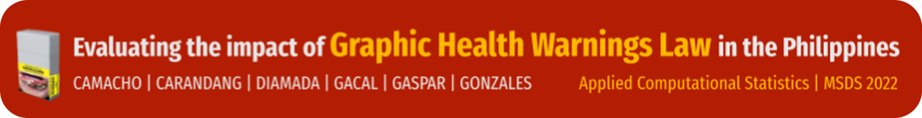